# R Shiny Labor Force Statistics

## [Interactive Project Link](https://ahmedtadde.shinyapps.io/laborviz/)

This is a data analysis writeup for the R [Shiny](http://shiny.rstudio.com/) application - **Labor Force Statistics**, built to visualize labor statistics trends over a number of variables e.g. races and genders.

## Summary

In this visualization application, we want to draw conclusions and trends about labor statistics in the US, by comparing employment and unemployment rates across races, genders, occupations, and education levels.

The original datasets are derived from the Current Population Survey ([CPS](http://www.bls.gov/cps/)) released by the Bureau of Labor Statistics. The native HTML table presentation of the data makes it difficult to *visualize and derive trends*.

Take a look at this:

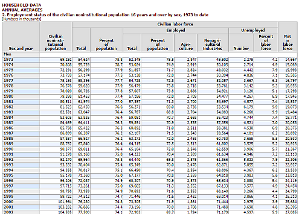

image-cps-02

as opposed to this:

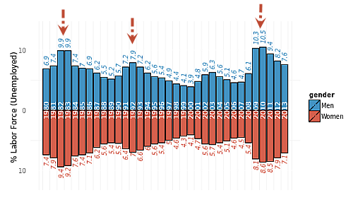

image-trend-unemployed-rate

We will delve into details on some interesting topics revolved around:

- Labor Force Trends ([cps-02](http://www.bls.gov/cps/cpsaat02.htm))
- Employment by Occupation ([cps-14](http://www.bls.gov/cps/cpsaat14.htm))
- Employment by Education ([cps-07](http://www.bls.gov/cps/cpsaat07.htm))

At any time, feel free to experiment and draw your own conclusions with the interactive web application and refer to the `.R` files found on the [Github](https://github.com/ahmedtadde/laborViz) project site if you need details on code implementation.

<sub>(back to contents)</sub>

## Labor Force Trends

### What does the US population look like?

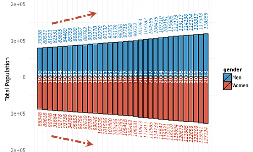

image-trend-population

It appears that the US population is still *growing*. In addition, note that the population of women is *higher* than men.

### So who is NOT working in the labor force?

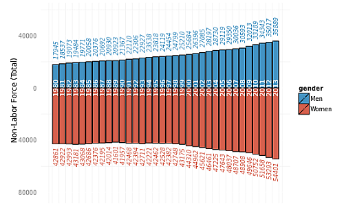

image-trend-non-labor-force

We see that a proportionately larger number of women are still not in the labor force, despite a slightly larger women population.

The next bar chart provides another view on the labor force by gender, by looking at employment *rates* instead of raw population headcount as displayed in the previous graph.

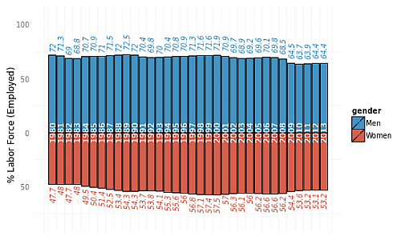

image-trend-employed-rate

We observe that there has been an increase in women being employed in the labor force over time (from 47.7% in 1980 to 53.2% in 2013). This is a good sign and hopefully things continue to trend towards gender equality.

### Should gender equality apply to all industries?

Let’s take a quick look at the *agriculture* industry sector, where we intuitively identify manual labor being employed more readily in men than women.

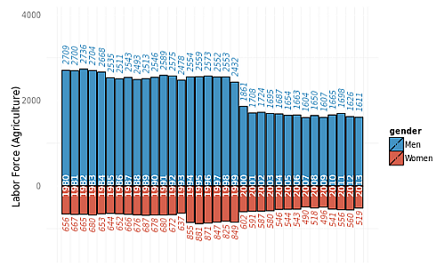

image-trend-agricultural-labor-force

Whoa! This makes intuitive sense, but there are some other interesting questions that can be gathered from this visualization:

1. *Why is there a slight jump in women agriculture labor force from 1994-1999?*
2. *Why is there a sudden decrease in agriculture labor force recent years after 2000?*

These are questions that require research outside of the dataset, but I thought a few resources that I read online are potentially interesting explanations for some of the questions raised out of curiosity:

1. I have not found a possible answer for this, but I’ll leave it for the audience to dig into why there is a slight jump in women agriculture labor force involvement from 1994-1999.
2. This maybe due to the fact that farm decline stabilized around 1997, as detailed in this [USDA article](http://www.usda.gov/factbook/chapter3.htm), as total land for farms remained the same after a decline in overall farms (i.e. farms stabilized into larger farms, which probably consolidated equipment and labor requirements over time)

### How about the unemployed?

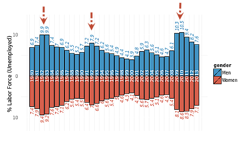

image-trend-unemployed-rate

From this bar chart, we see that both men and women suffer through economic recessions.

For some interesting facts, here are some details on major [recessions](http://en.wikipedia.org/wiki/List_of_recessions_in_the_United_States) that occurred in the US. I’m not an expert in labor statistics, but it seems that unemployment rates straggle a few more years after the recession periods before recovery. And we seem to be experiencing some kind of recession every 10 years, although this is more of an observation and not a conclusive statement with the small dataset we are working with

- [Early 1980s Recession](http://en.wikipedia.org/wiki/Early_1980s_recession) (1981 - 1982)
- [Early 1990s Recession](http://en.wikipedia.org/wiki/Early_1990s_recession) (1990 - 1991)
- [The Great Recession](http://en.wikipedia.org/wiki/Great_Recession) (2007 - 2009)

This wraps up some of the visualizations that I found interesting. Feel free to play with the webapp to discover more findings! In the next section, we will study in more detail how each race and gender group perform in various occupations and industries at certain age groups.

<sub>(back to contents)</sub>

## Employment by Occupation

### A quick overview

The next facet plot visualization helps us get a quick overview on relative percentages of employed people across genders and races in various occupations and industries, sliced by age groups.

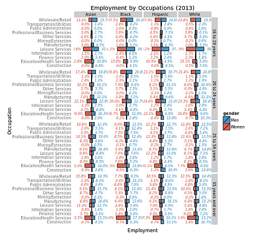

image-occupation-all

Some quick observations and comments:

- We will use percentages to convey the data instead of raw head counts, which will skew the visualization towards the **White** demographic.
- All percentages within a race (column) sums up to 100% in a given age group, this helps us determine the relative gender and racial distribution for each age group across occupations and industries.
- We observe that for age group 1 (16-19 years), most younger people in the labor force are engaged in **Wholesale/Retail** as well as **Leisure Services** occupations, and for age group 4 (55 years and older), most older people are engaging in **Education/Health Services**. This seems to make intuitive sense: younger people engage in industries that require higher energy and attention while older people fit better in less energetic industries.
- Men-dominated industries include **Transportation/Utilities**, **Mining/Extraction**, **Manufacturing**, and **Construction**, while women-dominated industries include **Education/Health Services**. The rest of the industry seem to have relatively equal gender distributions across all races.

### Men-Dominated Industries

Knowing that men are better suited at labor-intensive roles, we can take a closer look at the primary industry sector comprised of **Transportation/Utilities**, **Mining/Extraction**, **Manufacturing**, and **Construction**.

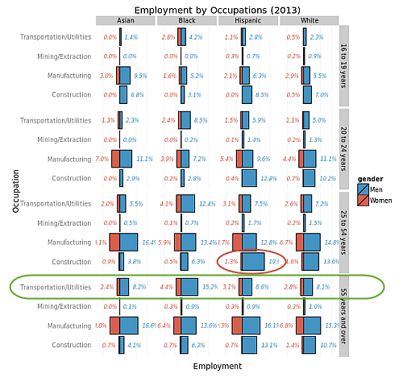

image-occupation-male-dominated

A few interesting things stand out:

- Most of the primary industry sector labor force is in the age group 2 and 3 (20-24 years and 25-54 years).
- We see a general trend of lower **Mining/Extraction** and **Construction** jobs in favor of **Transportation/Utilities** and **Manufacturing** jobs for the higher age groups, which makes intuitive sense as manual labor-intensive jobs are better suited for the younger population.
- There is another observation that Hispanic males are disproportionately involved in the **Construction** industry sector (as circled in red above, e.g. 19.9% Hispanics vs 13.6% White for age group 3)

By highlighting a specific age group (e.g. 20-24 years), and focusing on the blue columns which represent men labor force, we can see some variations among the races in the occupations they engage in.

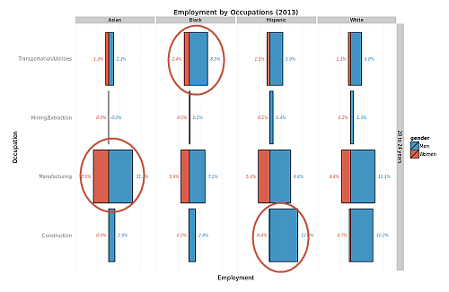

image-occupation-male-dominated-age-group-2

For age group 2 (20-24 years):

- Asians are engaged more in **Manufacturing**.
- Blacks are engaged more in **Transportation/Utilities**.
- Hispanics are engaged more in **Construction**
- Whites are engaged slightly more evenly in **Manufacturing** and **Construction**.

In the next sections, we will take a close look at some specific industries across the dimensions of race, gender and age groups.

### Education and Health Sector

First up, we have the **Education/Health** sector, where we can obviously identify it as a women-dominated sector.

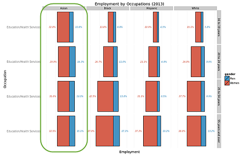

image-occupation-education-health

Here is a summary of the distribution across age groups in **Education/Health**:

- Asians have roughly equivalent distribution across age groups.
- All the other races seem to have growing distribution towards working in the **Education/Health** sector as the labor force gets older.

### Public Administration Sector

There is a clear increase of older labor force participating in the **Public Administration** industry sector, with roughly equal gender distributions.

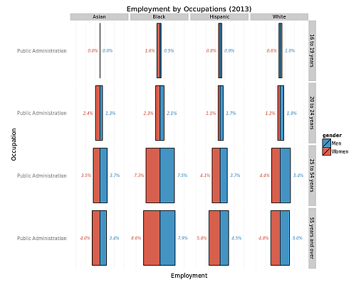

image-occupation-public-administration

### Business and Finance Sector

A quick look at the visualization suggests that younger people (age groups 1 and 2) are more engaged in **Wholesale/Retail**, while the older people (age groups 3 and 4) are engaged in **Professional/Business Services** and **Finance Services**.

Gender distributions across these service sector look roughly equivalent.

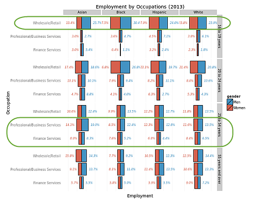

image-occupation-sales-business-finance

This wraps up some detailed facet plot visualizations of multi-dimensional analysis of labor force statistics across industry, occupations, gender, races and age groups.

<sub>(back to contents)</sub>

## Employment by Education

We all hear the saying that getting a Bachelor’s degree is *necessary* to finding jobs. We will take a deeper look into the dataset provided by CPS.

### By gender

Here are some quick numbers of the labor force by education level attainment.

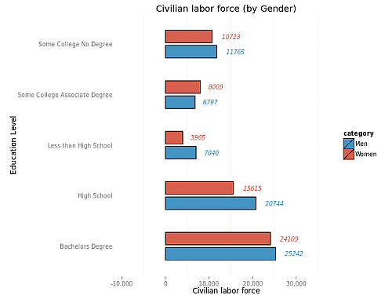

image-education-labor-force-by-gender

Most people in the US seem to have attained Bachelor degrees, or attended college with some associate or no degree.

When we zone in on the unemployment rates, we find an inverse correlation with educational level and unemployment rate. People holding bachelor degrees or attended college earning an associate degree have much lower unemployment rates than individuals who have not attended college or earned any degree.

Judging by the numbers, it is recommended that you should try to earn at least an associate degree in college, since the unemployment rates of graduating high school and attending college earning no degree are roughly the same.

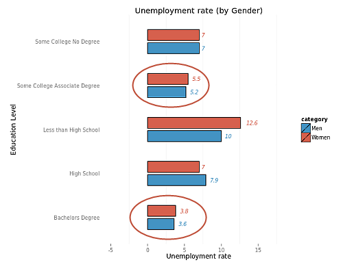

image-education-unemployment-by-gender

The next section filters the results by race instead of gender.

### By race

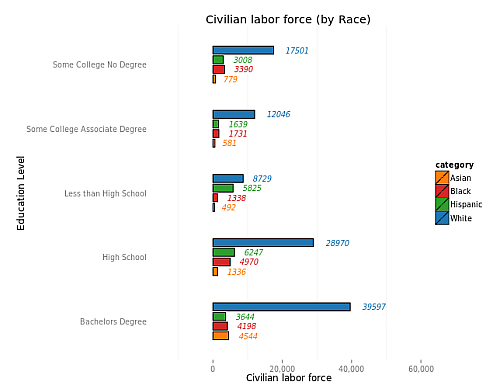

image-education-labor-force-by-race

The unemployment rate trend is essentially the same as we observed in the gender overview i.e. a higher education degree confers better chances of getting a job.

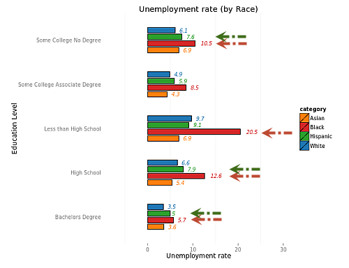

image-education-unemployment-by-race

<sub>(back to contents)</sub>

## Conclusion

> Despite the focus on expressing gender and racial equality statistics on labor force, I strongly believe that the topic of labor statistics should revolve around **ability equality** and not around gender and racial equality.

As seen in the example of agricultural jobs, women lack the natural ability to perform in this industry, and this should not be interpreted as discrimination when we evaluate people’s ability to do certain work.

We need to be careful about over-emphasizing the obsession in optimizing “gender/racial-equal” numbers, which in my opinion, is another form of discrimination by overly stressing the concepts of genders and races, when our ultimate goal is to hopefully not create concepts of races and genders when we are engaging in professional evaluations of people.

Our solutions in education and government policies should be geared towards empowering individuals with *equal opportunities* to pursue what they want to achieve in their careers, and it is very important that pre-employment education is provided for every individual fairly, so that the true test of employment can be judged on a merit basis, instead on trying to optimize “gender/racial-equal” metrics.

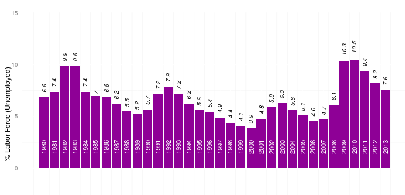

image-trend-all

<sub>(back to contents)</sub>

## Data Resources

- CPS data: [cps-02](http://www.bls.gov/cps/cpsaat02.htm), [cps-14](http://www.bls.gov/cps/cpsaat14.htm), [cps-07](http://www.bls.gov/cps/cpsaat07.htm)

<sub>(back to contents)</sub>